# Introduction

The project is contracted by the National Health Services (NHS), a publicly funded healthcare system in England. The NHS is concern about the utilisation of services, missed appointments, and the potential value of using external data sources such as Twitter (now rebranded as X).

## Approach

1. Familiar with business context and data sets.
2. Identify business questions.
3. Explore wrangle and visualise the data sets.
4. Identify trends and draw insights from the data.
5. Conclusion and recommendations.

# 1. Import libraries

```python
# Import the necessary libraries.
import pandas as pd
import numpy as np
import seaborn as sns
import matplotlib.pyplot as plt

# Set figure size.
sns.set(rc={'figure.figsize':(16, 10)})

# Set the plot style as white.
sns.set_style('dark')

# Font size of the axes titles.
plt.rc('axes', titlesize=25)

# Font size of the x and y labels.
plt.rc('axes', labelsize=21)

# Font size of the tick labels.
plt.rc('xtick', labelsize=17,color='#4f4e4e')
plt.rc('ytick', labelsize=17,color='#4f4e4e')

# Font size of the legend.
plt.rc('legend', fontsize=17)

# Default text size.
plt.rc('font', size=17)

# Ignore warnings.
import warnings
warnings.filterwarnings('ignore')
```

# Import files

### 'actual_duration'

Details of appointments made by patients. For example, the regional information, date, duration, and number of appointments pertaining to a certain class.

```python
# Import and sense-check the actual_duration.csv data.
ad = pd.read_csv('actual_duration.csv')

# View the DataFrame.
print(ad.shape)
print(ad.columns)
ad.head()
```

```
(137793, 8)
Index(['sub_icb_location_code', 'sub_icb_location_ons_code',
       'sub_icb_location_name', 'icb_ons_code', 'region_ons_code',
       'appointment_date', 'actual_duration', 'count_of_appointments'],
      dtype='object')
```

|  | sub_icb_location_code | sub_icb_location_ons_code | sub_icb_location_name | icb_ons_code | region_ons_code | appointment_date | actual_duration | count_of_appointments |
| --- | --- | --- | --- | --- | --- | --- | --- | --- |
| 0 | 00L | E38000130 | NHS North East and North Cumbria ICB - 00L | E54000050 | E40000012 | 01-Dec-21 | 31-60 Minutes | 364 |
| 1 | 00L | E38000130 | NHS North East and North Cumbria ICB - 00L | E54000050 | E40000012 | 01-Dec-21 | 21-30 Minutes | 619 |
| 2 | 00L | E38000130 | NHS North East and North Cumbria ICB - 00L | E54000050 | E40000012 | 01-Dec-21 | 6-10 Minutes | 1698 |
| 3 | 00L | E38000130 | NHS North East and North Cumbria ICB - 00L | E54000050 | E40000012 | 01-Dec-21 | Unknown / Data Quality | 1277 |
| 4 | 00L | E38000130 | NHS North East and North Cumbria ICB - 00L | E54000050 | E40000012 | 01-Dec-21 | 16-20 Minutes | 730 |

```python
# Determine whether there are missing values.
ad.isnull().sum()
```

```
sub_icb_location_code        0
sub_icb_location_ons_code    0
sub_icb_location_name        0
icb_ons_code                 0
region_ons_code              0
appointment_date             0
actual_duration              0
count_of_appointments        0
dtype: int64
```

```python
# Determine the metadata of the data set.
ad.info()
```

```
<class 'pandas.core.frame.DataFrame'>
RangeIndex: 137793 entries, 0 to 137792
Data columns (total 8 columns):
 #   Column                     Non-Null Count   Dtype
---  ------                     --------------   -----
 0   sub_icb_location_code      137793 non-null  object
 1   sub_icb_location_ons_code  137793 non-null  object
 2   sub_icb_location_name      137793 non-null  object
 3   icb_ons_code               137793 non-null  object
 4   region_ons_code            137793 non-null  object
 5   appointment_date           137793 non-null  object
 6   actual_duration            137793 non-null  object
 7   count_of_appointments      137793 non-null  int64
dtypes: int64(1), object(7)
memory usage: 8.4+ MB
```

```python
# Determine the descriptive statistics of the data set.
ad.describe()
```

|  | count_of_appointments |
| --- | --- |
| count | 137793.000000 |
| mean | 1219.080011 |
| std | 1546.902956 |
| min | 1.000000 |
| 25% | 194.000000 |
| 50% | 696.000000 |
| 75% | 1621.000000 |
| max | 15400.000000 |

### 'appointment_regional'

Details on the type of appointments made by patients. For example, regional information, the month of appointment, appointment status, healthcare professional, appointment mode, the time between booking and the appointment, as well as the number of appointments pertaining to a certain class.

```python
# Import and sense-check the appointments_regional.csv data.
ar = pd.read_csv('appointments_regional.csv')

# View the DataFrame.
print(ar.shape)
print(ar.columns)
ar.head()
```

```
(596821, 7)
Index(['icb_ons_code', 'appointment_month', 'appointment_status', 'hcp_type',
       'appointment_mode', 'time_between_book_and_appointment',
       'count_of_appointments'],
      dtype='object')
```

|  | icb_ons_code | appointment_month | appointment_status | hcp_type | appointment_mode | time_between_book_and_appointment | count_of_appointments |
| --- | --- | --- | --- | --- | --- | --- | --- |
| 0 | E54000034 | 2020-01 | Attended | GP | Face-to-Face | 1 Day | 8107 |
| 1 | E54000034 | 2020-01 | Attended | GP | Face-to-Face | 15 to 21 Days | 6791 |
| 2 | E54000034 | 2020-01 | Attended | GP | Face-to-Face | 2 to 7 Days | 20686 |
| 3 | E54000034 | 2020-01 | Attended | GP | Face-to-Face | 22 to 28 Days | 4268 |
| 4 | E54000034 | 2020-01 | Attended | GP | Face-to-Face | 8 to 14 Days | 11971 |

```python
# Determine whether there are missing values.
ar.isnull().sum()
```

```
icb_ons_code                         0
appointment_month                    0
appointment_status                   0
hcp_type                             0
appointment_mode                     0
time_between_book_and_appointment    0
count_of_appointments                0
dtype: int64
```

```python
# Determine the metadata of the data set.
ar.info()
```

```
<class 'pandas.core.frame.DataFrame'>
RangeIndex: 596821 entries, 0 to 596820
Data columns (total 7 columns):
 #   Column                             Non-Null Count   Dtype
---  ------                             --------------   -----
 0   icb_ons_code                       596821 non-null  object
 1   appointment_month                  596821 non-null  object
 2   appointment_status                 596821 non-null  object
 3   hcp_type                           596821 non-null  object
 4   appointment_mode                   596821 non-null  object
 5   time_between_book_and_appointment  596821 non-null  object
 6   count_of_appointments              596821 non-null  int64
dtypes: int64(1), object(6)
memory usage: 31.9+ MB
```

```python
# Determine the descriptive statistics of the data set.
ar.describe()
```

|  | count_of_appointments |
| --- | --- |
| count | 596821.000000 |
| mean | 1244.601857 |
| std | 5856.887042 |
| min | 1.000000 |
| 25% | 7.000000 |
| 50% | 47.000000 |
| 75% | 308.000000 |
| max | 211265.000000 |

### 'national_categories'

Details of the national categories of appointments made by patients. For example, the regional information, date of appointment, service setting, type of context, national category, and the number of appointments pertaining to a certain class.

```python
# Import and sense-check the national_categories.xlsx data.
nc = pd.read_excel('national_categories.xlsx')

# View the DataFrame.
print(nc.shape)
print(nc.columns)
nc.head()
```

```
(817394, 8)
Index(['appointment_date', 'icb_ons_code', 'sub_icb_location_name',
       'service_setting', 'context_type', 'national_category',
       'count_of_appointments', 'appointment_month'],
      dtype='object')
```

|  | appointment_date | icb_ons_code | sub_icb_location_name | service_setting | context_type | national_category | count_of_appointments | appointment_month |
| --- | --- | --- | --- | --- | --- | --- | --- | --- |
| 0 | 2021-08-02 | E54000050 | NHS North East and North Cumbria ICB - 00L | Primary Care Network | Care Related Encounter | Patient contact during Care Home Round | 3 | 2021-08 |
| 1 | 2021-08-02 | E54000050 | NHS North East and North Cumbria ICB - 00L | Other | Care Related Encounter | Planned Clinics | 7 | 2021-08 |
| 2 | 2021-08-02 | E54000050 | NHS North East and North Cumbria ICB - 00L | General Practice | Care Related Encounter | Home Visit | 79 | 2021-08 |
| 3 | 2021-08-02 | E54000050 | NHS North East and North Cumbria ICB - 00L | General Practice | Care Related Encounter | General Consultation Acute | 725 | 2021-08 |
| 4 | 2021-08-02 | E54000050 | NHS North East and North Cumbria ICB - 00L | General Practice | Care Related Encounter | Structured Medication Review | 2 | 2021-08 |

```python
# Determine whether there are missing values.
nc.isnull().sum()
```

```
appointment_date         0
icb_ons_code             0
sub_icb_location_name    0
service_setting          0
context_type             0
national_category        0
count_of_appointments    0
appointment_month        0
dtype: int64
```

```python
# Determine the metadata of the data set.
nc.info()
```

```
<class 'pandas.core.frame.DataFrame'>
RangeIndex: 817394 entries, 0 to 817393
Data columns (total 8 columns):
 #   Column                 Non-Null Count   Dtype
---  ------                 --------------   -----
 0   appointment_date       817394 non-null  datetime64[ns]
 1   icb_ons_code           817394 non-null  object
 2   sub_icb_location_name  817394 non-null  object
 3   service_setting        817394 non-null  object
 4   context_type           817394 non-null  object
 5   national_category      817394 non-null  object
 6   count_of_appointments  817394 non-null  int64
 7   appointment_month      817394 non-null  object
dtypes: datetime64[ns](1), int64(1), object(6)
memory usage: 49.9+ MB
```

```python
# Determine the descriptive statistics of the data set.
nc.describe()
```

|  | appointment_date | count_of_appointments |
| --- | --- | --- |
| count | 817394 | 817394.000000 |
| mean | 2022-01-16 00:50:35.860796160 | 362.183684 |
| min | 2021-08-01 00:00:00 | 1.000000 |
| 25% | 2021-10-25 00:00:00 | 7.000000 |
| 50% | 2022-01-18 00:00:00 | 25.000000 |
| 75% | 2022-04-07 00:00:00 | 128.000000 |
| max | 2022-06-30 00:00:00 | 16590.000000 |
| std | NaN | 1084.576600 |

### 'Regions'

Additional data set obtained from website https://www.england.nhs.uk/statistics/statistical-work-areas/ambulance-quality-indicators/ambulance-management-information/ which includes the regions of England based on icb_ons_code.

```python
# Import and sense-check the 'Regions' data.
regions = pd.read_csv('Regions.csv')

# View the DataFrame.
print(regions.shape)
print(regions.columns)
regions.head()
```

```
(42, 2)
Index(['icb_ons_code', 'region'], dtype='object')
```

|  | icb_ons_code | region |
| --- | --- | --- |
| 0 | E54000024 | East of England |
| 1 | E54000056 | East of England |
| 2 | E54000025 | East of England |
| 3 | E54000026 | East of England |
| 4 | E54000022 | East of England |

```python
# Determine whether there are missing values.
regions.isnull().sum()
```

```
icb_ons_code    0
region          0
dtype: int64
```

### 'Population 50 and above'

Additional data set obtained from Census 2021 https://www.nomisweb.co.uk/query/construct/summary.asp?reset=yes&mode=construct&dataset=2020&version=0&anal=1 which includes the information of population age.

```python
# Import and sense-check the data.
population = pd.read_csv('2021 Population 50 and above.csv')

# View the DataFrame.
print(population.shape)
print(population.columns)
population.head()
```

```
(7, 2)
Index(['region', 'population'], dtype='object')
```

|  | region | population |
| --- | --- | --- |
| 0 | North East & Yorkshire | 3229154 |
| 1 | North West | 2868560 |
| 2 | Midlands | 4216254 |
| 3 | East of England | 2500647 |
| 4 | London | 2547121 |

```python
# Determine whether there are missing values.
regions.isnull().sum()
```

```
icb_ons_code    0
region          0
dtype: int64
```

### 'tweets'

Data related to healthcare in the UK scraped from Twitter.

```python
# Load the data set.
tweets = pd.read_csv('tweets.csv')

# View the DataFrame.
print(tweets.shape)
print(tweets.columns)
print(tweets.describe())
print(tweets.info())
tweets.head()
```

```
(1174, 10)
Index(['tweet_id', 'tweet_full_text', 'tweet_entities',
       'tweet_entities_hashtags', 'tweet_metadata', 'tweet_retweet_count',
       'tweet_favorite_count', 'tweet_favorited', 'tweet_retweeted',
       'tweet_lang'],
      dtype='object')
           tweet_id  tweet_retweet_count  tweet_favorite_count
count  1.174000e+03          1174.000000            1174.00000
mean   1.567612e+18             8.629472               0.37138
std    2.427553e+13            29.784675               2.04470
min    1.567574e+18             0.000000               0.00000
25%    1.567590e+18             0.000000               0.00000
50%    1.567611e+18             1.000000               0.00000
75%    1.567633e+18             3.000000               0.00000
max    1.567655e+18           303.000000              42.00000
<class 'pandas.core.frame.DataFrame'>
RangeIndex: 1174 entries, 0 to 1173
Data columns (total 10 columns):
 #   Column                   Non-Null Count  Dtype
---  ------                   --------------  -----
 0   tweet_id                 1174 non-null   int64
 1   tweet_full_text          1174 non-null   object
 2   tweet_entities           1174 non-null   object
 3   tweet_entities_hashtags  1007 non-null   object
 4   tweet_metadata           1174 non-null   object
 5   tweet_retweet_count      1174 non-null   int64
 6   tweet_favorite_count     1174 non-null   int64
 7   tweet_favorited          1174 non-null   bool
 8   tweet_retweeted          1174 non-null   bool
 9   tweet_lang               1174 non-null   object
dtypes: bool(2), int64(3), object(5)
memory usage: 75.8+ KB
None
```

|  | tweet_id | tweet_full_text | tweet_entities | tweet_entities_hashtags | tweet_metadata | tweet_retweet_count | tweet_favorite_count | tweet_favorited | tweet_retweeted | tweet_lang |
| --- | --- | --- | --- | --- | --- | --- | --- | --- | --- | --- |
| 0 | 1567629223795527681 | As Arkansas’ first Comprehensive Stroke Certif... | {'hashtags': [{'text': 'Healthcare', 'indices'... | #Healthcare | {'iso_language_code': 'en', 'result_type': 're... | 0 | 0 | False | False | en |
| 1 | 1567582846612553728 | RT @AndreaGrammer: Work-life balance is at the... | {'hashtags': [{'text': 'PremiseHealth', 'indic... | #PremiseHealth, #hiring | {'iso_language_code': 'en', 'result_type': 're... | 2 | 0 | False | False | en |
| 2 | 1567582787070304256 | RT @OntarioGreens: $10 billion can go a long w... | {'hashtags': [{'text': 'Healthcare', 'indices'... | #Healthcare | {'iso_language_code': 'en', 'result_type': 're... | 39 | 0 | False | False | en |
| 3 | 1567582767625428992 | RT @modrnhealthcr: 🚨#NEW:🚨 Insurance companies... | {'hashtags': [{'text': 'NEW', 'indices': [20, ... | #NEW | {'iso_language_code': 'en', 'result_type': 're... | 5 | 0 | False | False | en |
| 4 | 1567582720460570625 | ICYMI: Our recent blogs on Cybersecurity in Ac... | {'hashtags': [{'text': 'blogs', 'indices': [18... | #blogs, #digitaltransformation, #cybersecurity... | {'iso_language_code': 'en', 'result_type': 're... | 0 | 0 | False | False | en |

```python
# Determine whether there are missing values.
tweets.isnull().sum()
```

```
tweet_id                     0
tweet_full_text              0
tweet_entities               0
tweet_entities_hashtags    167
tweet_metadata               0
tweet_retweet_count          0
tweet_favorite_count         0
tweet_favorited              0
tweet_retweeted              0
tweet_lang                   0
dtype: int64
```

```python
# Explore the metadata.
print(tweets['tweet_metadata'])
```

```
0       {'iso_language_code': 'en', 'result_type': 're...
1       {'iso_language_code': 'en', 'result_type': 're...
2       {'iso_language_code': 'en', 'result_type': 're...
3       {'iso_language_code': 'en', 'result_type': 're...
4       {'iso_language_code': 'en', 'result_type': 're...
                              ...
1169    {'iso_language_code': 'en', 'result_type': 're...
1170    {'iso_language_code': 'en', 'result_type': 're...
1171    {'iso_language_code': 'en', 'result_type': 're...
1172    {'iso_language_code': 'en', 'result_type': 're...
1173    {'iso_language_code': 'en', 'result_type': 're...
Name: tweet_metadata, Length: 1174, dtype: object
```

# 2. Data Exploration

**Question 1:** Between what dates were appointments scheduled?

```python
# Change the date format.
ad['appointment_date'] = pd.to_datetime(ad['appointment_date'])
ar['appointment_month'] = pd.to_datetime(ar['appointment_month'])

# View the DateFrame.
print(ad['appointment_date'].head())
print(ar['appointment_month'].head())
```

```
0   2021-12-01
1   2021-12-01
2   2021-12-01
3   2021-12-01
4   2021-12-01
Name: appointment_date, dtype: datetime64[ns]
0   2020-01-01
1   2020-01-01
2   2020-01-01
3   2020-01-01
4   2020-01-01
Name: appointment_month, dtype: datetime64[ns]
```

```python
# Determine the minimum and maximum dates in the ad DataFrame.
print(f"The minimum appointment date in 'actual_duration': ", ad['appointment_date'].min())
print(f"The maximum appointment date in 'actual_duration': ", ad['appointment_date'].max())
print(f"The minimum appoinment date in 'national_categories': ", nc['appointment_date'].min())
print(f"The maximum appoinment date in 'national_categories': ", nc['appointment_date'].max())
print(f"The minimum appoinment month in 'appointments_regional': ", ar['appointment_month'].min())
print(f"The maximum appoinment month in 'appointments_regional': ", ar['appointment_month'].max())
```

```
The minimum appointment date in 'actual_duration':  2021-12-01 00:00:00
The maximum appointment date in 'actual_duration':  2022-06-30 00:00:00
The minimum appoinment date in 'national_categories':  2021-08-01 00:00:00
The maximum appoinment date in 'national_categories':  2022-06-30 00:00:00
The minimum appoinment month in 'appointments_regional':  2020-01-01 00:00:00
The maximum appoinment month in 'appointments_regional':  2022-06-01 00:00:00
```

The recorded appointments scheduled are different in all three data sets. In ad, the duration is between Dec 2021 and June 2022, over a period of 7 months. In nc, the duration is between Aug 2021 and June 2022, over a period of 11 months. In ar, the appointments scheduled is recorded on monthly basis only, from Jan 2020 to June 2022. The appointment_month data is converted to datetime so the default date is being displayed.

The analysis is focused on the period after Aug 2021 to ensure the analysis is not afected by the global pandemic (Fong, K. J., Summers, C. and Cook, T. M. (2024) ‘NHS hospital capacity during covid-19: overstretched staff, space, systems, and stuff’, BMJ. BMJ Publishing Group Ltd, 385. doi: 10.1136/bmj-2023-075613).

**Question 2:** Which month had the highest number of appointments?

#### ad

```python
# Add new column for appointment year.
ad['appointment_year'] = ad['appointment_date'].dt.year

# Use groupby() to group data according to year and month.
ad_grouped = ad.groupby([ad['appointment_year'], ad['appointment_date'].dt.month])

# Sum the count of appointment by year and month.
ad_monthly_total = ad_grouped['count_of_appointments'].sum().reset_index()

# View the DataFrame.
print(ad_monthly_total.sort_values(by='count_of_appointments', ascending=False))
```

```
   appointment_year  appointment_date  count_of_appointments
3              2022                 3               27170002
5              2022                 5               25343941
6              2022                 6               23715317
1              2022                 1               23597196
2              2022                 2               23351939
0              2021                12               22853483
4              2022                 4               21948814
```

#### nc

```python
# Change the data type.
nc['appointment_month'] = pd.to_datetime(nc['appointment_month'])
print(nc['appointment_month'].head())

# Add new column for appointment year
nc['appointment_year'] = nc['appointment_month'].dt.year

# Use groupby() to group data according to year and month.
nc_grouped = nc.groupby([nc['appointment_year'], nc['appointment_month'].dt.month])

# Sum the count of appointment by year and month.
nc_monthly_total = nc_grouped['count_of_appointments'].sum().reset_index()

# View the DataFrame.
print(nc_monthly_total.sort_values(by='count_of_appointments', ascending=False))
```

```
0   2021-08-01
1   2021-08-01
2   2021-08-01
3   2021-08-01
4   2021-08-01
Name: appointment_month, dtype: datetime64[ns]
    appointment_year  appointment_month  count_of_appointments
3               2021                 11               30405070
2               2021                 10               30303834
7               2022                  3               29595038
1               2021                  9               28522501
9               2022                  5               27495508
10              2022                  6               25828078
5               2022                  1               25635474
6               2022                  2               25355260
4               2021                 12               25140776
8               2022                  4               23913060
0               2021                  8               23852171
```

#### ar

```python
# Filtered the period.
ar_filtered = ar[ar['appointment_month']>='2021-08-01']
print(ar_filtered.shape)

# Add new column for appointment year
ar_filtered['appointment_year'] = ar_filtered['appointment_month'].dt.year

# Use groupby() to group data according to year and month.
ar_filtered_grouped = ar_filtered.groupby([ar_filtered['appointment_year'],
                                           ar_filtered['appointment_month'].dt.month])

# Sum the count of appointment by year and month.
ar_monthly_total = ar_filtered_grouped['count_of_appointments'].sum().reset_index()

# View the DataFrame.
print(ar_monthly_total.sort_values(by='count_of_appointments', ascending=False))
```

```
(223418, 7)
    appointment_year  appointment_month  count_of_appointments
3               2021                 11               30405070
2               2021                 10               30303834
7               2022                  3               29595038
1               2021                  9               28522501
9               2022                  5               27495508
10              2022                  6               25828078
5               2022                  1               25635474
6               2022                  2               25355260
4               2021                 12               25140776
8               2022                  4               23913060
0               2021                  8               23852171
```

2021-11 had the highest number of appointments, followed by 2021-10, according to nc and ar data. This is the months where wether's getting colder, transition between autumn and winter. The month with the third highest number of appointments is 2022-3, the month between the transition of winter and spring.

Note that the monthly number of appointments in ad file is different from nc and ar data sets. Hence, most of the analysis is based on nc and ar data sets.

**Question 3:** How many locations are there in the data set?

```python
# Determine the number of locations.
print(f"Count of locations from nc file: ", nc['sub_icb_location_name'].nunique())
print(f"Count of locations from ad file: ", ad['sub_icb_location_name'].nunique())
```

```
Count of locations from nc file:  106
Count of locations from ad file:  106
```

**Question 4:** How many service settings, context types, national categories, appointment status and appointment mode are there?

```python
# Determine the number of service settings.
print(nc['service_setting'].value_counts())
print(f"Count of service settings: ", nc['service_setting'].nunique())
```

```
service_setting
General Practice             359274
Primary Care Network         183790
Other                        138789
Extended Access Provision    108122
Unmapped                      27419
Name: count, dtype: int64
Count of service settings:  5
```

```python
# Determine the number of context types.
print(nc['context_type'].value_counts())
print(f"Count of context_type: ", nc['context_type'].nunique())
```

```
context_type
Care Related Encounter    700481
Inconsistent Mapping       89494
Unmapped                   27419
Name: count, dtype: int64
Count of context_type:  3
```

```python
# Determine the number of national categories.
print(nc['national_category'].value_counts())
print(f"Count of national_category: ", nc['national_category'].nunique())
```

```
national_category
Inconsistent Mapping                                                   89494
General Consultation Routine                                           89329
General Consultation Acute                                             84874
Planned Clinics                                                        76429
Clinical Triage                                                        74539
Planned Clinical Procedure                                             59631
Structured Medication Review                                           44467
Service provided by organisation external to the practice              43095
Home Visit                                                             41850
Unplanned Clinical Activity                                            40415
Patient contact during Care Home Round                                 28795
Unmapped                                                               27419
Care Home Visit                                                        26644
Social Prescribing Service                                             26492
Care Home Needs Assessment & Personalised Care and Support Planning    23505
Non-contractual chargeable work                                        20896
Walk-in                                                                14179
Group Consultation and Group Education                                  5341
Name: count, dtype: int64
Count of national_category:  18
```

```python
# Determine the number of appointment status.
print(ar['appointment_status'].value_counts())
print(f"Count of appointment_status: ", ar['appointment_status'].nunique())
```

```
appointment_status
Attended    232137
Unknown     201324
DNA         163360
Name: count, dtype: int64
Count of appointment_status:  3
```

```python
# Determine the number of appointment mode.
print(ar['appointment_mode'].value_counts())
print(f"Count of appointment_status: ", ar['appointment_mode'].nunique())
```

```
appointment_mode
Face-to-Face    180410
Telephone       166483
Home Visit      111194
Unknown          79147
Video/Online     59587
Name: count, dtype: int64
Count of appointment_status:  5
```

# 3. Merging of Data Sets

#### ar_re

```python
# Merge ar with 'Regions'.
ar_re = pd.merge(ar_filtered, regions,
                 on='icb_ons_code', how='outer')

# View the DataFrame
print(ar_re.shape)
print(ar_re.columns)
ar_re.head()
```

```
(223418, 9)
Index(['icb_ons_code', 'appointment_month', 'appointment_status', 'hcp_type',
       'appointment_mode', 'time_between_book_and_appointment',
       'count_of_appointments', 'appointment_year', 'region'],
      dtype='object')
```

|  | icb_ons_code | appointment_month | appointment_status | hcp_type | appointment_mode | time_between_book_and_appointment | count_of_appointments | appointment_year | region |
| --- | --- | --- | --- | --- | --- | --- | --- | --- | --- |
| 0 | E54000008 | 2021-08-01 | Attended | GP | Face-to-Face | 1 Day | 1218 | 2021 | North West |
| 1 | E54000008 | 2021-08-01 | Attended | GP | Face-to-Face | 15 to 21 Days | 395 | 2021 | North West |
| 2 | E54000008 | 2021-08-01 | Attended | GP | Face-to-Face | 2 to 7 Days | 1613 | 2021 | North West |
| 3 | E54000008 | 2021-08-01 | Attended | GP | Face-to-Face | 22 to 28 Days | 219 | 2021 | North West |
| 4 | E54000008 | 2021-08-01 | Attended | GP | Face-to-Face | 8 to 14 Days | 591 | 2021 | North West |

```python
# Determine whether there are missing values.
ar_re.isnull().sum()
```

```
icb_ons_code                         0
appointment_month                    0
appointment_status                   0
hcp_type                             0
appointment_mode                     0
time_between_book_and_appointment    0
count_of_appointments                0
appointment_year                     0
region                               0
dtype: int64
```

#### nc_re

```python
# Merge nc with 'Regions'.
nc_re = pd.merge(nc, regions,
                 on='icb_ons_code', how='outer')

# View the DataFrame
print(nc_re.shape)
print(nc_re.columns)
nc_re.head()
```

```
(817394, 10)
Index(['appointment_date', 'icb_ons_code', 'sub_icb_location_name',
       'service_setting', 'context_type', 'national_category',
       'count_of_appointments', 'appointment_month', 'appointment_year',
       'region'],
      dtype='object')
```

|  | appointment_date | icb_ons_code | sub_icb_location_name | service_setting | context_type | national_category | count_of_appointments | appointment_month | appointment_year | region |
| --- | --- | --- | --- | --- | --- | --- | --- | --- | --- | --- |
| 0 | 2021-08-02 | E54000008 | NHS Cheshire and Merseyside ICB - 01F | Primary Care Network | Inconsistent Mapping | Inconsistent Mapping | 17 | 2021-08-01 | 2021 | North West |
| 1 | 2021-08-02 | E54000008 | NHS Cheshire and Merseyside ICB - 01F | Other | Inconsistent Mapping | Inconsistent Mapping | 37 | 2021-08-01 | 2021 | North West |
| 2 | 2021-08-02 | E54000008 | NHS Cheshire and Merseyside ICB - 01F | Other | Care Related Encounter | Clinical Triage | 1 | 2021-08-01 | 2021 | North West |
| 3 | 2021-08-02 | E54000008 | NHS Cheshire and Merseyside ICB - 01F | General Practice | Inconsistent Mapping | Inconsistent Mapping | 320 | 2021-08-01 | 2021 | North West |
| 4 | 2021-08-02 | E54000008 | NHS Cheshire and Merseyside ICB - 01F | General Practice | Care Related Encounter | Planned Clinics | 153 | 2021-08-01 | 2021 | North West |

# 4. Capacity Status and Utilisation of Resources

**Question 1:** What is the capacity status of the NHS?

```python
# Create a subset.
nc_monthly = nc.groupby('appointment_month', as_index=False)\
                    [['count_of_appointments']].sum()

# Add a new column for percentage capacity.
nc_monthly['percentage_capacity'] = (nc_monthly['count_of_appointments']
                                     / (1200000*30))*100

# Convert the appointment_month to string data type for ease of visualisation.
nc_monthly['appointment_month'] = nc_monthly['appointment_month'].dt.strftime('%Y-%m')

nc_monthly
```

|  | appointment_month | count_of_appointments | percentage_capacity |
| --- | --- | --- | --- |
| 0 | 2021-08 | 23852171 | 66.256031 |
| 1 | 2021-09 | 28522501 | 79.229169 |
| 2 | 2021-10 | 30303834 | 84.177317 |
| 3 | 2021-11 | 30405070 | 84.458528 |
| 4 | 2021-12 | 25140776 | 69.835489 |
| 5 | 2022-01 | 25635474 | 71.209650 |
| 6 | 2022-02 | 25355260 | 70.431278 |
| 7 | 2022-03 | 29595038 | 82.208439 |
| 8 | 2022-04 | 23913060 | 66.425167 |
| 9 | 2022-05 | 27495508 | 76.376411 |
| 10 | 2022-06 | 25828078 | 71.744661 |

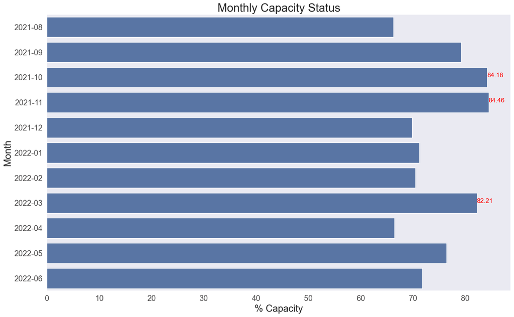

```python
# Create a plot.
ax = sns.barplot(x='percentage_capacity', y='appointment_month',
            data=nc_monthly)

# Customise plot setting
plt.title("Monthly Capacity Status")
plt.ylabel("Month")
plt.xlabel("% Capacity")

# Annotate points where y > 0.8
for i, row in nc_monthly.iterrows():
    if row['percentage_capacity'] > 80:
        ax.annotate(f'{row["percentage_capacity"]:.2f}',
                    xy=(row['percentage_capacity'], row['appointment_month']),
                    fontsize=14,
                    color='red')

# Save the plot.
plt.tight_layout()
plt.savefig('Monthly Capacity Status.png')
```

From the chart, more than 60% of capacity had been utilised throughout the analysis period and some of the months had exceeded 80%.

**Question 2:** What are the five locations with the highest number of appointments?

```python
# Determine the top five locations based on record count.
Total_count_of_appointments = nc.groupby('sub_icb_location_name', as_index=False)\
                                         [['count_of_appointments']].sum()

print(Total_count_of_appointments.sort_values
      (by='count_of_appointments', ascending=False).head())
```

```
                          sub_icb_location_name  count_of_appointments
76            NHS North West London ICB - W2U3Z               12142390
67            NHS North East London ICB - A3A8R                9588891
47                NHS Kent and Medway ICB - 91Q                9286167
36  NHS Hampshire and Isle Of Wight ICB - D9Y0V                8288102
82              NHS South East London ICB - 72Q                7850170
```

**Question :** Which service setting had the highest of usage?

```python
# Create a new DataFrame and aggregate.
nc_ss = nc.groupby(['appointment_month', 'service_setting'],
                   as_index=False)['count_of_appointments'].sum()

# Filter the DataFrame with only needed information.
nc_ss = nc_ss[(nc_ss['service_setting']!='Unmapped')]\
           .sort_values(by='count_of_appointments', ascending=False)

# View output.
nc_ss.head()
```

|  | appointment_month | service_setting | count_of_appointments |
| --- | --- | --- | --- |
| 16 | 2021-11-01 | General Practice | 27767889 |
| 11 | 2021-10-01 | General Practice | 27606171 |
| 36 | 2022-03-01 | General Practice | 27187368 |
| 6 | 2021-09-01 | General Practice | 25940821 |
| 46 | 2022-05-01 | General Practice | 25238620 |

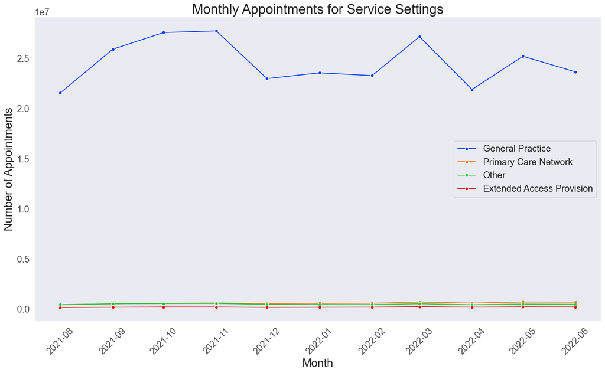

```python
# Create a lineplot.
sns.lineplot(x='appointment_month', y='count_of_appointments',
             hue='service_setting', data=nc_ss,
             marker='o', palette='bright')
plt.legend(loc='best')
plt.title("Monthly Appointments for Service Settings")
plt.ylabel("Number of Appointments")
plt.xlabel("Month")
plt.xticks(rotation=45)

# Save the plot.
plt.tight_layout()
plt.savefig('Monthly Appointments for Service Settings.png')
```

**Question 3:** Which service setting had the highest of usage based on regions?

```python
# Determine the total number of appointments per service setting.
nc_re_ss = nc_re.groupby(['service_setting', 'region'], as_index=False)\
                 [['count_of_appointments']].sum()

# Filter DataFrame with only needed information.
nc_re_ss = nc_re_ss[(nc_re_ss['service_setting']!='Unmapped')]\
           .sort_values(by='count_of_appointments', ascending=False)

# View the DataFrame.
nc_re_ss.head()
```

|  | service_setting | region | count_of_appointments |
| --- | --- | --- | --- |
| 9 | General Practice | Midlands | 52585341 |
| 10 | General Practice | North East & Yorkshire | 43295847 |
| 12 | General Practice | South East | 41677513 |
| 8 | General Practice | London | 40050508 |
| 11 | General Practice | North West | 33457086 |

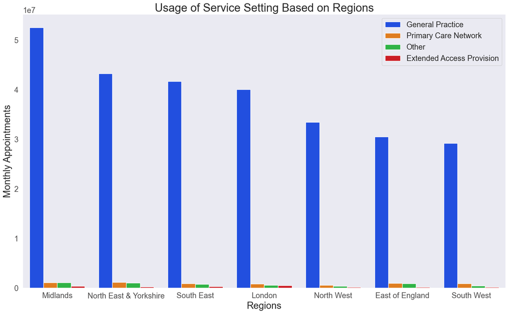

```python
# Create a bar plot to answer the question.
sns.barplot(x='region', y='count_of_appointments',
            hue='service_setting', data=nc_re_ss, palette='bright')
plt.legend(loc='best')
plt.title("Usage of Service Setting Based on Regions")
plt.ylabel("Monthly Appointments")
plt.xlabel("Regions")

# Save the plot.
plt.tight_layout()
plt.savefig('Usage of Service Setting Based on Regions.png')
```

General practice has the highest demand across all the regions.

```python
# Define season.
def get_season(date):
    month = date.month
    if month in [6, 7, 8]:
        return 'Summer'
    elif month in [9, 10, 11]:
        return 'Autumn'
    elif month in [12, 1, 2]:
        return 'Winter'
    else:
        return 'Spring'

nc['season'] = nc['appointment_month'].apply(get_season)

# Group the service setting in summer
nc_ss_season = nc.groupby(['season', 'service_setting'],
                          as_index=False)['count_of_appointments'].sum()

# Custom order for seasons.
season_order = ['Summer', 'Autumn', 'Winter', 'Spring']

# Convert 'stage' to a categorical column with the custom order
nc_ss_season['season'] = pd.Categorical(nc_ss_season['season'],
                                        categories=season_order, ordered=True)

# Sort by that column.
nc_ss_season = nc_ss_season.sort_values(by='season')

# Filter the DataFrame with only needed information.
nc_ss_season = nc_ss_season[(nc_ss_season['service_setting']!='Unmapped')]\
           .sort_values(by='count_of_appointments', ascending=False)

# View output.
nc_ss_season.head()
```

|  | season | service_setting | count_of_appointments |
| --- | --- | --- | --- |
| 1 | Autumn | General Practice | 81314881 |
| 6 | Spring | General Practice | 74342779 |
| 16 | Winter | General Practice | 69897805 |
| 11 | Summer | General Practice | 45256226 |
| 8 | Spring | Primary Care Network | 2020726 |

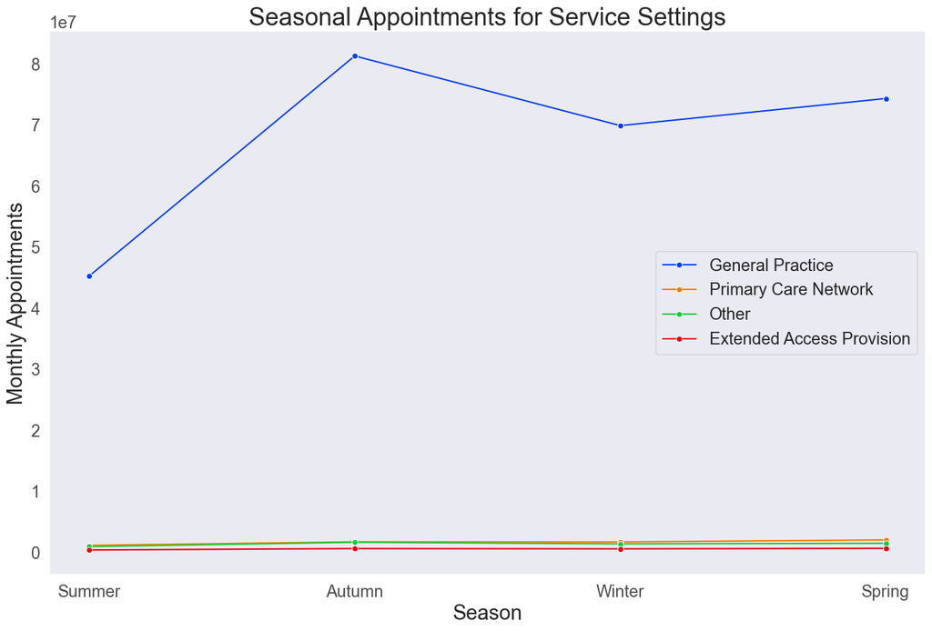

```python
# Create a lineplot.
sns.lineplot(x='season', y='count_of_appointments',
             hue='service_setting', data=nc_ss_season,
             marker='o', palette='bright')
plt.legend(loc='best')
plt.title("Seasonal Appointments for Service Settings")
plt.ylabel("Monthly Appointments")
plt.xlabel("Season")
```

**Question 5:** Which national categories had the highest number of appointments?

```python
# Create a separate data set that can be used in future weeks.
nc_nc = nc.groupby(['appointment_month', 'national_category'],
                   as_index=False)['count_of_appointments'].sum()\
                   .sort_values(by='count_of_appointments', ascending=False)

# View output.
nc_nc.head()
```

|  | appointment_month | national_category | count_of_appointments |
| --- | --- | --- | --- |
| 130 | 2022-03-01 | General Consultation Routine | 10074249 |
| 58 | 2021-11-01 | General Consultation Routine | 9778682 |
| 166 | 2022-05-01 | General Consultation Routine | 9320538 |
| 40 | 2021-10-01 | General Consultation Routine | 9256788 |
| 22 | 2021-09-01 | General Consultation Routine | 9060243 |

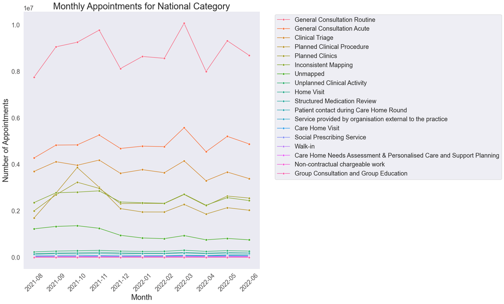

```python
# Set the plot size.
plt.figure(figsize=(20, 12))

# Create a lineplot.
sns.lineplot(x='appointment_month', y='count_of_appointments',
             hue='national_category', data=nc_nc, marker='o')
plt.legend(bbox_to_anchor=(1.05, 1), loc='upper left')
plt.title("Monthly Appointments for National Category")
plt.ylabel("Number of Appointments")
plt.xlabel("Month")
plt.xticks(fontsize=17, rotation=45)
plt.yticks(fontsize=17)

# Save the plot.
plt.tight_layout()
plt.savefig('Monthly Appointments for National Category.png')
```

From the graph, we can see that the Top 3 category are general consultation routine, general consultation acute and clinical triage. According to NHS (https://www.england.nhs.uk/long-read/recording-gp-appointments-consolidated-guidance/), the categories used for urgent needs are

- General Consultation Acute
- Unplanned clinical activity
- Walk-in
- Clinical triage

So, 2 out of 3 top category are under urgent needs.

**Question 6:** Is there any relationship between the monthly appointment and population age based on regions?

```python
# Load the file.
population = pd.read_csv('2021 Population 50 and above.csv')

# Merge ar_regions with '2021 Senior Citizen Population'.
nc_re_pop = pd.merge(nc_re, population,
                     on='region', how='outer')

# View the DataFrame
print(nc_re_pop.shape)

# Check for missing data.
nc_re_pop.isnull().sum()
```

```
(817394, 11)
```

```
appointment_date         0
icb_ons_code             0
sub_icb_location_name    0
service_setting          0
context_type             0
national_category        0
count_of_appointments    0
appointment_month        0
appointment_year         0
region                   0
population               0
dtype: int64
```

```python
# Create a subset.
nc_re_pop_grouped = nc_re_pop.groupby(['region', 'population'], as_index=False)\
                    [['count_of_appointments']].sum().\
                    sort_values(by=['count_of_appointments'], ascending=False)

# View the DataFrame.
nc_re_pop_grouped
```

|  | region | population | count_of_appointments |
| --- | --- | --- | --- |
| 2 | Midlands | 4216254 | 57352329 |
| 3 | North East & Yorkshire | 3229154 | 47915966 |
| 5 | South East | 3663610 | 45003534 |
| 1 | London | 2547121 | 43484439 |
| 4 | North West | 2868560 | 35865459 |
| 0 | East of England | 2500647 | 34055047 |
| 6 | South West | 2452437 | 32369996 |

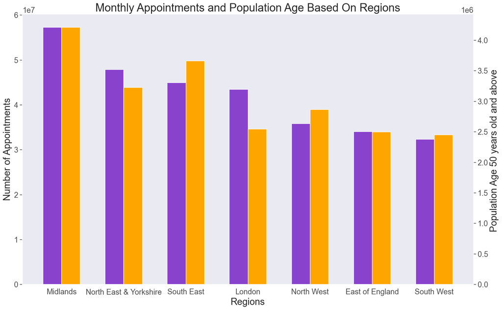

```python
# Set up the figure and first axis
fig, ax1 = plt.subplots(figsize=(16, 10))

# Bar width and position tweak
bar_width = 0.3
x = np.arange(len(nc_re_pop_grouped['region']))

# Create a bar plot with first y-axis.
sns.barplot(x='region', y='count_of_appointments', width=bar_width,
            data=nc_re_pop_grouped, ax=ax1, color='blueviolet')
ax1.set_ylabel("Number of Appointments")
plt.xlabel("Regions")

# Create a second y-axis sharing the same x-axis
ax2 = ax1.twinx()

# Create a bar plot with second y-axis.
ax2.bar(x + bar_width, nc_re_pop_grouped['population'], width=bar_width,
        color='orange', label='Population')
ax2.set_ylabel("Population Age 50 years old and above ")

# Adjust x-ticks to center between the two bars
ax1.set_xticks(x + bar_width / 2)
ax1.set_xticklabels(nc_re_pop_grouped['region'])

plt.title("Monthly Appointments and Population Age Based On Regions")

# Save the plot.
plt.tight_layout()
plt.savefig('Monthly Appointments and Population Age Based On Regions.png')
```

Midlands has the highest monthly appointments. In general, the monthly appointments are increased with the increase of the population with people older than 50 years old.

# 5. Missed Appointments

**Question 1**: How often appointments are missed?

```python
# Create a new DataFrame for monthly appointments.
ar_monthly = ar_filtered.groupby(['appointment_month'])\
                            [['count_of_appointments']].sum().reset_index()

# Create a new DataFrame for monthly appointment based on appointment status.
ar_status = ar_filtered.groupby(['appointment_status', 'appointment_month'])\
                            [['count_of_appointments']].sum().reset_index()

ar_merge = pd.merge(ar_monthly, ar_status, on='appointment_month', how='outer')

# Create a column for percentage of appointment.
ar_merge['%_appointment'] = ((ar_merge['count_of_appointments_y'])\
                            /(ar_merge['count_of_appointments_x']))*100

# Create a new DataFrame, include only needed information.
ar_merge_new = ar_merge[(ar_merge['appointment_status']!='Unknown')]

#View the DataFrame
ar_merge_new.head()
```

|  | appointment_month | count_of_appointments_x | appointment_status | count_of_appointments_y | %_appointment |
| --- | --- | --- | --- | --- | --- |
| 0 | 2021-08-01 | 23852171 | Attended | 22081765 | 92.577590 |
| 1 | 2021-08-01 | 23852171 | DNA | 949137 | 3.979248 |
| 3 | 2021-09-01 | 28522501 | Attended | 25757066 | 90.304374 |
| 4 | 2021-09-01 | 28522501 | DNA | 1321348 | 4.632651 |
| 6 | 2021-10-01 | 30303834 | Attended | 27170506 | 89.660292 |

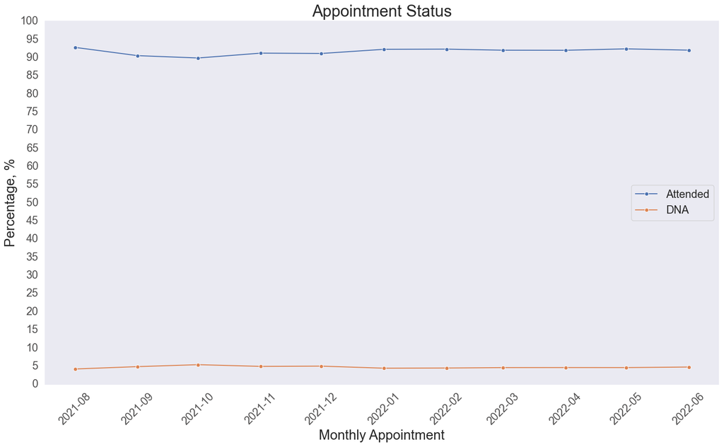

```python
# Create a line plot to answer the question.
sns.lineplot(x='appointment_month', y='%_appointment',
            hue='appointment_status', data=ar_merge_new, marker='o')
plt.legend(loc='best')
plt.title("Appointment Status")
plt.ylabel("Percentage, %")
plt.yticks(ticks=[0,5,10,15,20,25,30,35,40,45,50,55,60,65,70,75,80,85,90,95,100])
plt.xlabel("Monthly Appointment")
plt.xticks(rotation=45)

# Save the plot.
plt.tight_layout()
plt.savefig('Appointment Status.png')
```

There're roughly 5% of missed appointment and the percentage remains almost the same throughout the investigated period. This shows the missed appointment is not affected by the total monthly appointment and seasons.

**Question 2:** Are there any relationship betweeen the appointment status and the time between book and appointment?

```python
# Create a new DataFrame for time between booking and appointments.
ar_time = ar_filtered.groupby(['time_between_book_and_appointment'])\
                             [['count_of_appointments']].sum().reset_index()

# Create a new DataFrame for based on appointment status.
ar_status = ar_filtered.groupby(['time_between_book_and_appointment', 'appointment_status'])\
                               [['count_of_appointments']].sum().reset_index()

ar_merge2 = pd.merge(ar_time, ar_status, on='time_between_book_and_appointment', how='outer')

# Create a column for percentage of appointment.
ar_merge2['%_appointment'] = ((ar_merge2['count_of_appointments_y'])\
                            /(ar_merge2['count_of_appointments_x']))*100

# Create a new DataFrame, include only needed information.
ar_merge2_new = ar_merge2[(ar_merge2['appointment_status']=='Attended')&
                (ar_merge2['time_between_book_and_appointment']!='Unknown / Data Quality')]\
                .sort_values(by='%_appointment', ascending=False)

#View the DataFrame
ar_merge2_new
```

|  | time_between_book_and_appointment | count_of_appointments_x | appointment_status | count_of_appointments_y | %_appointment |
| --- | --- | --- | --- | --- | --- |
| 18 | Same Day | 130976642 | Attended | 125798420 | 96.046454 |
| 0 | 1 Day | 25872974 | Attended | 24012214 | 92.808094 |
| 6 | 2 to 7 Days | 60734100 | Attended | 54639327 | 89.964825 |
| 12 | 8 to 14 Days | 37507051 | Attended | 32528864 | 86.727330 |
| 3 | 15 to 21 Days | 19454328 | Attended | 16512807 | 84.879863 |
| 9 | 22 to 28 Days | 11430584 | Attended | 9480045 | 82.935789 |
| 15 | More than 28 Days | 9880538 | Attended | 7546107 | 76.373442 |

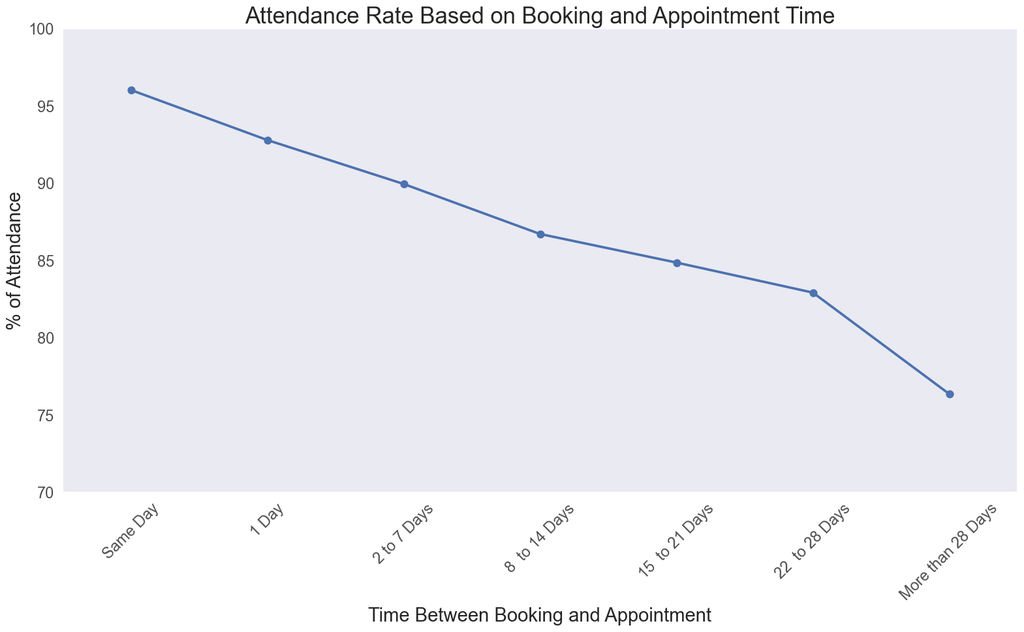

```python
# Create a line plot to answer the question.
sns.pointplot(x='time_between_book_and_appointment', y='%_appointment',
              data=ar_merge2_new)
plt.title("Attendance Rate Based on Booking and Appointment Time")
plt.ylabel("% of Attendance")
plt.yticks(ticks=[70,75,80,85,90,95,100])
plt.xlabel("Time Between Booking and Appointment")
plt.xticks(rotation=45)

# Save the plot.
plt.tight_layout()
plt.savefig('Attendance Rate Based on Booking and Appointment Time.png')
```

**Question 3:** Are there any relationship betweeen the appointment status and the appointment mode?

```python
# Create a new DataFrame based on time between book and appointment.
ar_mode = ar_filtered.groupby(['appointment_mode'])\
                            [['count_of_appointments']].sum().reset_index()

# Create new DataFrame based on appointment status.
ar_mode_status = ar_filtered.groupby(['appointment_mode', 'appointment_status'])\
                             [['count_of_appointments']].sum().reset_index()

ar_merge3 = pd.merge(ar_mode, ar_mode_status,
                     on='appointment_mode', how='outer')

ar_merge3

# Create a column for percentage of appointment.
ar_merge3['%_appointment'] = ((ar_merge3['count_of_appointments_y'])\
                             /(ar_merge3['count_of_appointments_x']))*100

# Create a new DataFrame, includes only needed information.
ar_merge3_new = ar_merge3[(ar_merge3['appointment_status']=='Attended')&
                (ar_merge3['appointment_mode']!='Unknown')]\
                .sort_values(by='%_appointment', ascending=False)

# View the output.
ar_merge3_new
```

|  | appointment_mode | count_of_appointments_x | appointment_status | count_of_appointments_y | %_appointment |
| --- | --- | --- | --- | --- | --- |
| 6 | Telephone | 100274881 | Attended | 95363359 | 95.101942 |
| 12 | Video/Online | 1543497 | Attended | 1416110 | 91.746858 |
| 0 | Face-to-Face | 183503587 | Attended | 164524501 | 89.657376 |
| 3 | Home Visit | 1991144 | Attended | 1514429 | 76.058236 |

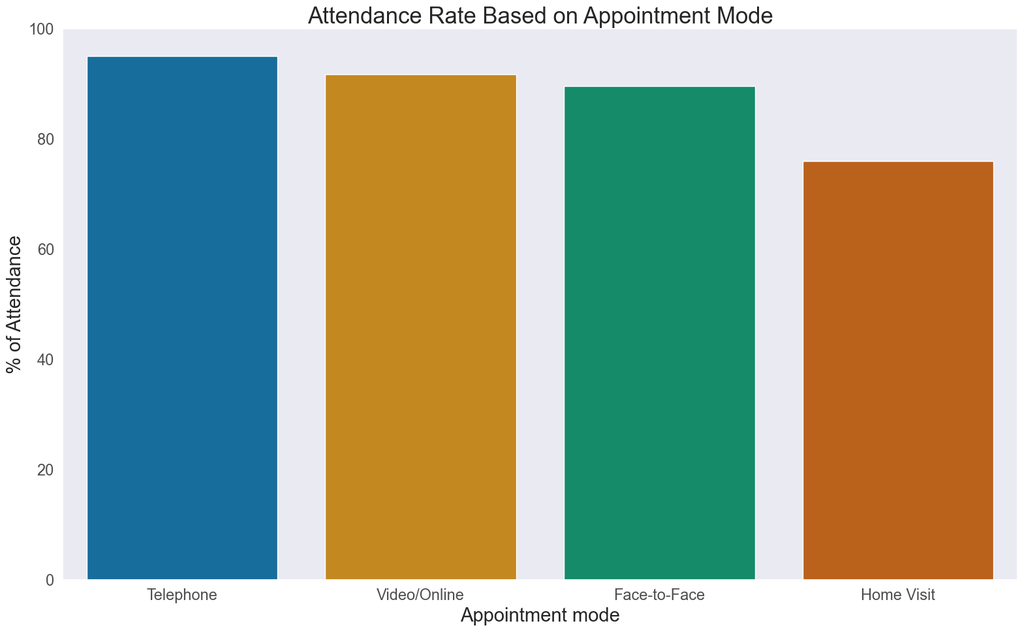

```python
# Create a bar plot to answer the question.
sns.barplot(x='appointment_mode', y='%_appointment',
              data=ar_merge3_new, palette='colorblind')
plt.title("Attendance Rate Based on Appointment Mode")
plt.ylabel("% of Attendance")
plt.xlabel("Appointment mode")
plt.yticks(ticks=[0,20,40,60,80,100])

# Save the plot.
plt.tight_layout()
plt.savefig('Attendance Rate Based on Appointment Mode.png')
```

# 6. External Resources 'X'

**Question 1:** What is the most popular hashtag related to healthcare in UK?

```python
# Create an empty list.
tags = []

# Loop through the messages, and create a list of values containing the # symbol.
for y in [x.split(' ') for x in tweets['tweet_full_text'].values]:
    for z in y:
        if '#' in z:
            # Change to lowercase.
            tags.append(z.lower())

# Create a series.
t = pd.Series(tags)

# Count the values.
tag_counts = t.value_counts().sort_values(ascending=False)

# Display the first 30 records.
print(tag_counts[:30])
```

```
#healthcare                    716
#health                         80
#medicine                       41
#ai                             40
#job                            38
#medical                        35
#strategy                       30
#pharmaceutical                 28
#digitalhealth                  25
#pharma                         25
#marketing                      25
#competitiveintelligence        24
#medtwitter                     24
#biotech                        24
#meded                          23
#vaccine                        18
#hiring                         18
#news                           17
#machinelearning                17
#technology                     17
#covid                          16
#competitivemarketing           16
#womeninmedicine                16
#coronavirus                    16
#wellness                       15
#healthtech                     15
#doctorofveterinarymedicine     14
#science                        14
#medicare                       14
#covid19                        14
Name: count, dtype: int64
```

```python
# Convert the series to a DataFrame in preparation for visualisation.
data = pd.DataFrame(tag_counts).reset_index()

# Rename the columns.
data.columns = ['word', 'count']

# View the df.
print(data.dtypes)
data.head()
```

```
word     object
count     int64
dtype: object
```

|  | word | count |
| --- | --- | --- |
| 0 | #healthcare | 716 |
| 1 | #health | 80 |
| 2 | #medicine | 41 |
| 3 | #ai | 40 |
| 4 | #job | 38 |

```python
# Display records where the count is larger than 10.
pop_tags = data[data['count']>10]

pop_tags.head()
```

|  | word | count |
| --- | --- | --- |
| 0 | #healthcare | 716 |
| 1 | #health | 80 |
| 2 | #medicine | 41 |
| 3 | #ai | 40 |
| 4 | #job | 38 |

```
              word  count
0      #healthcare    716
1          #health     80
2        #medicine     41
3              #ai     40
4             #job     38
5         #medical     35
6        #strategy     30
7  #pharmaceutical     28
8   #digitalhealth     25
9          #pharma     25
```

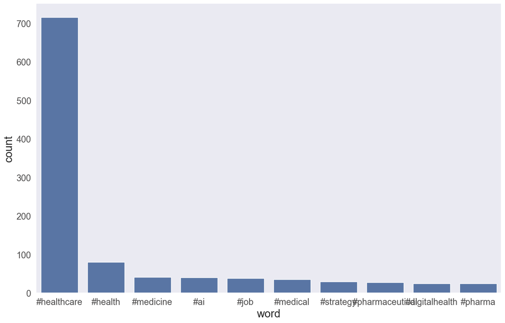

```python
# Create a Seaborn barplot indicating records with a count >10 records.
# Showing only the top 10.
# Create the plot.
top_counts = pop_tags.head(10)
print(top_counts)
# View the barplot.
sns.barplot(x='word', y='count', data=top_counts)
```

The most popular hastag is 'healthcare' from the data set.